# Final Project:

- Show All Code
- Hide All Code
- View Source

Predicting Eviction Counts by Census Tract in Philadelphia

Author

Huda Abdelnur, Dalanda Jalloh, Yusuf Khalil Muhammad, Wesley Nay

Published

May 8, 2026

# Executive Summary

This project uses Philadelphia eviction filing data to identify which census tracts are most at risk of future eviction filings. The goal is to help city officials and housing stability organizations target prevention resources earlier and more effectively, rather than responding only after filings have already occurred. More specifically, this project asks whether past eviction patterns and neighborhood-level socioeconomic conditions can be used to predict future eviction filings across Philadelphia census tracts. To answer this question, we combined Princeton Eviction Lab data from 2020–2026 with Census/ACS indicators, OpenDataPhilly data, 311 maintenance complaints, bike network and landmark data, and information on Philadelphia’s top eviction filers.

Our results concluded that predictive analytics can help identify areas where outreach, legal assistance, rental support, and landlord accountability efforts may be most needed. However, the model should not be used on its own to label neighborhoods as “high risk.” Because the data is aggregated by tract and reflects filings rather than completed evictions, the model identifies broader geographic patterns of housing instability rather than predicting which individual households will face eviction. As a result, predictive models should be paired with community knowledge, equity safeguards, and further investigation before guiding policy decisions.

# Policy and Theoretical Background

Eviction filings are closely associated with broader patterns of housing instability, financial hardship, and displacement. Even when a filing does not ultimately result in a formal eviction judgment, the filing process itself can create barriers to stable housing and contribute to future housing insecurity (National Low Income Housing Coalition, 2023). Research has also shown that eviction and housing instability are linked to increased risks of homelessness, economic hardship, and neighborhood instability. Because prevention resources such as rental assistance, legal aid, mediation programs, and tenant outreach are limited, cities increasingly rely on data-driven approaches to identify where housing instability may be intensifying before displacement occurs.

Philadelphia and other cities have already implemented eviction diversion and prevention strategies that depend on tracking filing patterns and targeting interventions toward vulnerable households and neighborhoods (City of Philadelphia, 2021). Predictive models can therefore help planners and policymakers allocate limited resources more proactively and monitor changing patterns of neighborhood vulnerability over time. At the same time, predictive analytics raises important ethical and methodological concerns. Ideally, eviction risk would be modeled at the household level, since there is substantial variation within individual census tracts. However, because eviction data is highly sensitive and household-level information is not publicly available, this model relies on aggregated tract-level data. While access to more granular administrative records would likely improve predictive accuracy and allow for more targeted interventions, predictive models should still be understood as tools to supplement existing community knowledge, tenant protections, and direct engagement with affected neighborhoods.

## Research Question

**Can we predict in which census tracts evictions are likely to occur based on where they occurred in the past?**

# 1. Data and Methods

## 1.1 Set Up

### 1.1.1 Load Required Packages

```r
library(tidyr)
library(ggplot2)
library(dplyr)
library(lubridate)
library(sf)
library(tigris)
library(tidycensus)
library(viridis)
library(knitr)
library(kableExtra)
library(patchwork)
library(scales)
library(here)
library(stringr)
library(ggspatial)
library(MASS)
options(scipen = 999)
```

First, we loaded the packages needed for data cleaning, spatial analysis, visualization, Census data access, and model evaluation. These packages allow us to work with tabular data, spatial layers, ACS variables, maps, and regression models within a single workflow.

## 1.2 Data Preparation

### 1.2.1 Load and Clean Eviction Filing Data

For this report, we are using eviction filing data spanning 2020-April 2026. This data is made available online through the Eviction Lab and was accessed through this link: https://evictionlab.org/eviction-tracking/philadelphia-pa/

First, we are loading in our eviction filing data from the Eviction Lab.

```r
eviction_data <- read.csv("data/philadelphia_weekly_2020_2021.csv")

check_one_tract <- eviction_data %>%
  filter(GEOID == "42101027200")

#I changed the data-set to get the census tracts and to make sure all the evictions were located in Philadelphia
eviction_data <- eviction_data %>%
  mutate(
    state  = substr(GEOID, 1, 2),
    county = substr(GEOID, 3, 5),
    tract  = paste0("Census Tract ", as.numeric(substr(GEOID, 6, 11)) / 100)
  ) %>%
  filter(state == "42", county == "101")

#Added the month and year as seperate columns
eviction_data<- eviction_data %>%
  mutate(year = year(week_date),
         month= month(week_date))

#I'm adding a season column
eviction_data<- eviction_data %>%
 mutate(season = case_when(
    month %in% c(12, 1, 2) ~ "winter",
    month %in% c(3, 4, 5) ~ "spring",
    month %in% c(6, 7, 8) ~ "summer",
    TRUE ~ "fall"
  ))

monthly_filings <- read.csv("data/philadelphia_barchart.csv")

filings_monthly <- read.csv("data/philadelphia_monthly_2020_2021.csv")

#This breaks down the filings for each month, year and census tract
eviction_data_1<- eviction_data %>%
  group_by(GEOID, tract, year, month) %>%
  summarise(n= sum(filings_2020))

eviction_data_1<- eviction_data_1 %>%
  rename(GEOID10= "GEOID")
```

### 1.2.2 Load Census Tract Boundaries

```r
#Philadelphia census tract boundaries

census_tracts<- st_read("data/census_tracts.shp")
if (st_crs(census_tracts)$epsg != 2272) {
  census_tracts <- st_transform(census_tracts, 2272)
}
```

After we loaded in eviction_data, we also wanted to check and explore the columns to find our unit of analysis and understand the structure of the data frame. To do this, we filter eviction_data to just one census tract by picking one GEOID. This is a data quality checking step that helps us understand the structure of data and confirm that each row represents eviction filing for a specific census tract and week.

We then create additional time variables from the weekly filing date. The `year` and `month` variables allow us to summarize and compare filing patterns over time, while the `season` variable allows us to test whether eviction filings vary across winter, spring, summer, and fall. Including season is useful because eviction filings may follow temporal patterns that are not captured by geography alone.

The monthly Eviction Lab files are also loaded for comparison and exploratory analysis. While the main modeling dataset uses weekly tract-level filings (eviction_data), the monthly data can help validate broader trends and provide simpler summaries for visualization. We also aggregate the weekly data by census tract, year, and month to create a monthly tract-level summary. This gives us a more flexible version of the data for exploratory analysis and mapping.

Finally, we load the Philadelphia census tract boundary shapefile. This spatial layer is necessary for mapping eviction filings and for joining other spatial datasets to census tracts. We transform the tract boundaries to EPSG:2272 when needed, which is a projected coordinate reference system appropriate for Philadelphia-area spatial analysis. Using a consistent projected CRS helps ensure that spatial joins and maps align correctly throughout the analysis.

# 2. Exploratory Data Analysis

Housing eviction patterns are not consistent throughout the year, with key differences occurring by season. For example, during the winter season additional costs go towards utilities, which may increase financial burden on those who are already cost burdened, ultimately making them more prone to not being able to pay rent. Additionally, the holiday season during the winter may cause people to increase spending on other priorities outside of rent. Another season that may have an impact on eviction filings is the summer. Considering the city of Philadelphia houses multiple universities, creating an environment where the rate at which students are moving to the city may incentivize landlords to proceed with eviction filings to create rooms for new tenants. It is also very common for leases to begin during the summer with the beginning of the academic year, thus creating further incentives for landlords to increase eviction filings. These considerations were taken into account, and a plot was created to examine average weekly filings: the results in fact revealed seasons impact eviction filing trends. The highest average weekly filing was in the winter which may be due to the aforementioned issues of increased spending due to utilities and holidays, this was followed by fall, summer, then spring with lowest weekly average filings.

## 2.1 Temporal Patterns in Eviction Filings

### 2.1.1 Weekly Filings Within a Single Census Tract

This code chunk below was just to visually experiment with a single census tract.

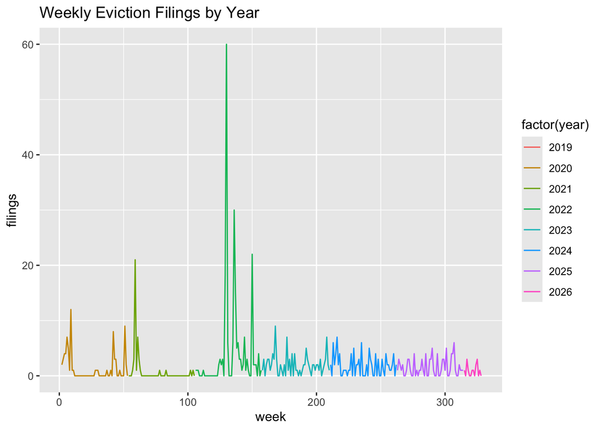

```r
##Map all years

##Plot all years for a single tract
check_one_tract %>%
  mutate(year = lubridate::year(week_date)) %>%
  group_by(year, week) %>%
  summarize(
    filings = sum(filings_2020, na.rm = TRUE),
    .groups = "drop"
  ) %>%
  ggplot(aes(x = week, y = filings, color = factor(year))) +
  geom_line() +
  labs(title = "Weekly Eviction Filings by Year")
```

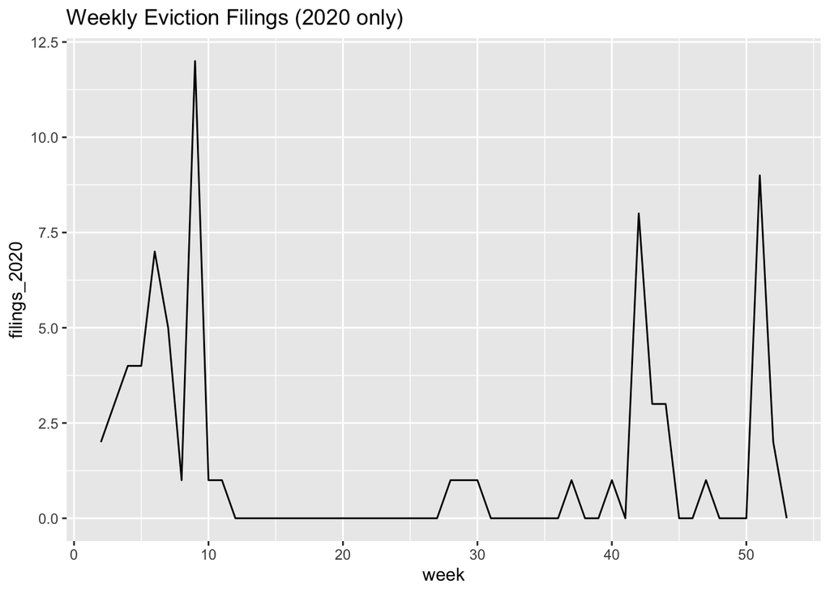

```r
#Code to plot weekly filings in 2020 for one tract

check_one_tract %>%
  filter(lubridate::year(week_date) == 2020) %>%
  group_by(week) %>%
  summarize(
    filings_2020 = sum(filings_2020, na.rm = TRUE)
  ) %>%
  ggplot(aes(x = week, y = filings_2020)) +
  geom_line() +
  labs(title = "Weekly Eviction Filings (2020 only)")
```

### 2.1.2 Citywide Weekly Eviction Filing Trends

Weekly eviction filings for every year.

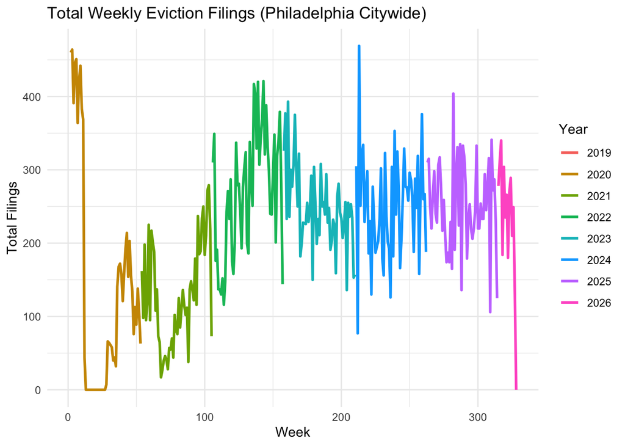

```r
# Total citywide filings per week}
weekly_plot <- eviction_data %>%
  mutate(year = lubridate::year(week_date)) %>%
  group_by(year, week) %>%
  summarize(
    total_filings = sum(filings_2020, na.rm = TRUE),
    .groups = "drop"
  ) %>%
  ggplot(aes(x = week, y = total_filings, color = factor(year))) +
  geom_line(linewidth = 1) +
  labs(
    title = "Total Weekly Eviction Filings (Philadelphia Citywide)",
    x = "Week",
    y = "Total Filings",
    color = "Year"
  ) +
  theme_minimal()

weekly_plot
```

### 2.1.3 Distribution of Eviction Filings

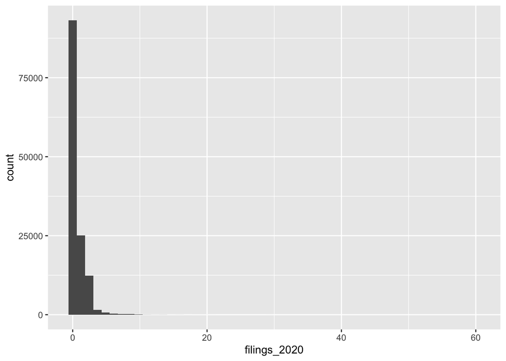

```r
##Histogram
ggplot(eviction_data, aes(x = filings_2020)) +
  geom_histogram(bins = 50)
```

### 2.1.4 Seasonal Filing Patterns

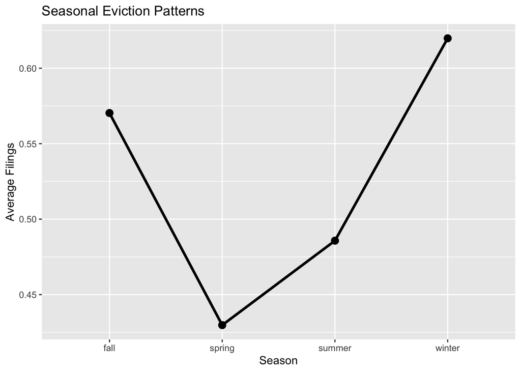

```r
##seasonal patterns
seasonal_patterns <- eviction_data %>%
  group_by(season) %>%
  summarize(
    avg_filings = mean(filings_2020, na.rm = TRUE),
    .groups = "drop"
  )


ggplot(seasonal_patterns, aes(x = season, y = avg_filings, group = 1)) +
  geom_line(linewidth = 1.2) +
  geom_point(size = 3) +
  labs(
    title = "Seasonal Eviction Patterns",
    x = "Season",
    y = "Average Filings"
  )
```

## 2.2 Spatial Patterns of Eviction Filings

### 2.2.1 Average Eviction Filings by Census Tract

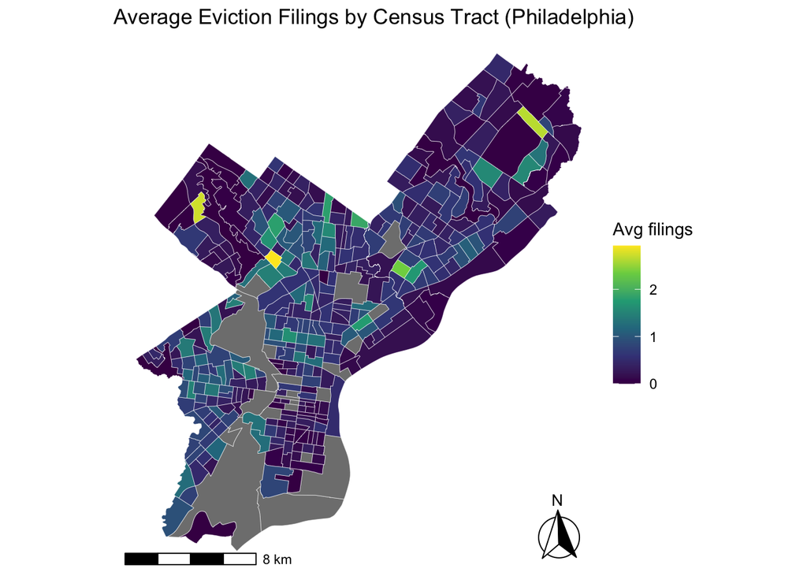

```r
##Map
eviction_tract <- eviction_data %>%
  group_by(GEOID) %>%
  summarize(
    avg_filings = mean(filings_2020, na.rm = TRUE),
    total_filings = sum(filings_2020, na.rm = TRUE),
    persistence = mean(filings_2020 > 0, na.rm = TRUE),
    .groups = "drop"
  )

census_tracts <- census_tracts %>%
  rename(GEOID = GEOID10)

philly_map <- census_tracts %>%
  left_join(eviction_tract, by = "GEOID")


eviction_map <- ggplot(philly_map) +
  geom_sf(aes(fill = avg_filings), color = "white", linewidth = 0.1) +
  scale_fill_viridis_c() +

  # --- North arrow ---
  annotation_north_arrow(
    location = "br",   # top right
    which_north = "true",
    style = north_arrow_fancy_orienteering
  ) +

  # --- Scale bar ---
  annotation_scale(
    location = "bl",   # bottom left
    width_hint = 0.3
  ) +

  labs(
    title = "Average Eviction Filings by Census Tract (Philadelphia)",
    fill = "Avg filings"
  ) +
  theme_void()

eviction_map
```

# 3. Constructing Predictor Variables

## 3.1 Built Environment Variables

```r
bike_data<- st_read("data/Bike_Network.shp")
bike_data <- st_transform(bike_data, st_crs(census_tracts))

bike_census<- st_join(bike_data, census_tracts, join = st_intersects) %>%
  group_by(NAMELSAD10) %>%
  tally()


eviction_tracts_unique <- eviction_data %>%
  distinct(tract)

setequal(bike_census$NAMELSAD10, eviction_tracts_unique$tract)
```

```
[1] FALSE
```

```r
setdiff(bike_census$NAMELSAD10, eviction_tracts_unique$tract)
```

```
 [1] "Census Tract 1"     "Census Tract 12.02" "Census Tract 125"
 [4] "Census Tract 13"    "Census Tract 137"   "Census Tract 142"
 [7] "Census Tract 160"   "Census Tract 188"   "Census Tract 207"
[10] "Census Tract 369"   "Census Tract 383"   "Census Tract 390"
[13] "Census Tract 4.02"  "Census Tract 41.02" "Census Tract 50"
[16] "Census Tract 69"    "Census Tract 7"     "Census Tract 8.04"
[19] "Census Tract 9800"  "Census Tract 9807"  "Census Tract 9809"
[22] NA
```

```r
bad_tracts <- setdiff(bike_census$NAMELSAD10, eviction_tracts_unique$tract)

bike_census <- bike_census %>%
  filter(!NAMELSAD10 %in% bad_tracts)

bike_census<- bike_census %>%
  rename(tract= NAMELSAD10)
```

Bike infrastructure was included as a built environment proxy to test whether neighborhood infrastructure patterns are associated with eviction filing activity. Bike data was obtained from Open Data Philly and joined to the census tracts. Census tracts were filtered to only the ones where evictions occurred. The number of bike lanes present in each census tract was then determined using a summarize function.

### 3.1.2 Landmarks

```r
landmarks<- st_read("data/Landmark_Points.shp")
landmarks_subtype<- landmarks %>%
  group_by(SUBTYPE) %>%
  tally()

landmarks<- st_transform(landmarks, st_crs(census_tracts))

landmarks<- st_join(landmarks, census_tracts)

landmarks<- landmarks %>%
  dplyr::select(NAME, TYPE, SUBTYPE, NAMELSAD10) %>%
  st_drop_geometry() %>%
  group_by(NAMELSAD10) %>%
   summarise(landmarks = n()) %>%
  rename(tract= NAMELSAD10)
```

Landmark density was included as a proxy for neighborhood activity, institutional concentration, and land use intensity. Landmark data was obtained from Open Data Philly and joined to census tracts. Census tracts were filtered to only the ones where evictions occurred. The number of landmarks present in each census tract was then determined using a summarize function.

## 3.2 Census and Socioeconomic Variables

### 3.2.1 Demographic Variables

```r
census<- get_acs(
  geography = "tract",
  variables = c(
    "B19013_001",  # Median household income
    "B08301_010E",  # Transit commuters
    "B01002_001E" #Median age
  ),
  state = "PA",
  county = "Philadelphia",
  year = 2024,
  geometry = TRUE,
  output = "wide",
  progress_bar = FALSE
)%>%
  rename(
    Med_Inc = B19013_001E,
    Transit_Commuters = B08301_010E,
    Median_age= B01002_001E
  )

census <- st_transform(census, 2272)

# Verify
st_crs(census)$epsg
```

```
[1] 2272
```

To capture the demographics and socioeconomic of the population, data was collected from 2024 ACS Census Data. These variables provide an understanding of major indicators of eviction such as median income, age and transit commuters.

### 3.2.2 Residential Mobility

```r
philly_mobility <- get_acs(
  geography = "tract",
  variables = c(
    "B07003_001",
    "B07003_004",
    "B07003_007",
    "B07003_010",
    "B07003_013",
    "B07003_016"
  ),
  state = "PA",
  county = "Philadelphia",
  year = 2024,
  geometry = TRUE,
  output = "wide"
)

# Rename
philly_mobility <- philly_mobility %>%
  rename(
    total_pop_1yr = B07003_001E,
    same_house = B07003_004E,
    moved_same_county = B07003_007E,
    moved_diff_county_same_state = B07003_010E,
    moved_diff_state = B07003_013E,
    moved_abroad = B07003_016E
  )

philly_mobility <- philly_mobility %>%
  mutate(shareof_newres =  round(((moved_same_county + moved_diff_county_same_state + moved_diff_state + moved_abroad) / total_pop_1yr * 100), 1)) %>%
  dplyr::select(-B07003_001M, -B07003_004M, -B07003_007M, -B07003_010M, -B07003_013M,-B07003_016M, -NAME) %>%
  st_drop_geometry()
```

Residential mobility was included as a proxy for gentrification. If a neighborhood is highly desired and landlords see people moving in, this may be an indicator of gentrification. This variable seeks to measure if mobility of any socioeconomic group (wealth, race) is an indicator of increased eviction filings. Data was obtained from the 2024 ACS census.

### 3.2.3 Vehicle Access

```r
philly_vehicles <- get_acs(
  geography = "tract",
  variables = c(
    "B08201_001",  # Total households
    "B08201_002"   # No vehicle available
  ),
  state = "PA",
  county = "Philadelphia",
  year = 2024,
  geometry = TRUE,
  output = "wide",
  progress_bar = FALSE
)

# Rename and calculate share
philly_vehicles <- philly_vehicles %>%
  rename(
    total_households = B08201_001E,
    no_vehicle = B08201_002E
  ) %>%
  mutate(share_no_vehicle = round((no_vehicle / total_households * 100), 1)) %>% dplyr::select(-B08201_001M, -B08201_002M, -NAME) %>%
  st_drop_geometry()
```

Vehicle ownership was added to the model as a proxy of employment stability. Vehicle ownership rate in Philadelphia is high, with around 70% of households owning at least one car. Additionally, households in areas such as Northeast and Northwest Philadelphia rely more heavily on vehicles due to poorer transit connectivity and longer commute times. This data was obtained from 2024 ACS data.

### 3.2.4 Race and Ethnicity

```r
philly_race <- get_acs(
  geography = "tract",
  variables = c(
    "B03002_001",  # Total population
    "B03002_004",  # Black alone
    "B03002_012"   # Hispanic or Latino
  ),
  state = "PA",
  county = "Philadelphia",
  year = 2024,
  geometry = TRUE,
  output = "wide",
  progress_bar = FALSE
)

# Rename and calculate shares
philly_race <- philly_race %>%
  rename(
    total_pop = B03002_001E,
    black = B03002_004E,
    hispanic_latino = B03002_012E
  ) %>%
  mutate(
    share_black = round((black / total_pop * 100), 1),
    share_hispanic = round((hispanic_latino / total_pop * 100), 1)) %>%
  dplyr::select(-B03002_001M, -B03002_004M, -B03002_012M, -NAME) %>%
  st_drop_geometry()
```

Literature reveals that eviction filings are more likely in African American/ Black and Hispanic households. Therefore, these variables were added to the model for their potentially strong predictive power. Data was obtained from the 2024 ACS Census.

### 3.2.5 Rent Burden

```r
philly_rent_burden <- get_acs(
  geography = "tract",
  variables = c(
    "B25070_001",  # Total renter-occupied households
    "B25070_007",  # 30.0 to 34.9 percent
    "B25070_008",  # 35.0 to 39.9 percent
    "B25070_009",  # 40.0 to 49.9 percent
    "B25070_010"   # 50.0 percent or more
  ),
  state = "PA",
  county = "Philadelphia",
  year = 2024,
  geometry = TRUE,
  output = "wide",
  progress_bar = FALSE
)

# Rename and calculate share
philly_rent_burden <- philly_rent_burden %>%
  rename(
    total_renters = B25070_001E,
    burden_30_34 = B25070_007E,
    burden_35_39 = B25070_008E,
    burden_40_49 = B25070_009E,
    burden_50plus = B25070_010E
  ) %>%
  mutate(
    rent_burdened_30plus = burden_30_34 + burden_35_39 + burden_40_49 + burden_50plus,
    share_rent_burdened = round((rent_burdened_30plus / total_renters * 100), 1)
  ) %>%
  st_drop_geometry()
```

Rent burden was added to the model because rent burden and eviction are highly correlated. The more likely one is unable to pay their rent, they more likely they are to default on rent payments. The definition of rent burden used was that of the Department of Housing and Urban Development (HUD).

# 4. Building the Modeling Dataset

## 4.1 Creating the Census Tract-Week Panel

```r
#selecting what i need from eviction data
eviction_panel<- eviction_data %>%
  dplyr::select(GEOID, racial_majority, week, week_date, filings_2020, tract, year, month, season )

# joining the other features so far into the panel
#landmarks
eviction_panel<- left_join(eviction_panel, landmarks, by= "tract")

##bike
eviction_panel<- left_join(eviction_panel, bike_census, by= "tract")

eviction_panel <- eviction_panel %>%
  rename(bikeln = n)
#census variables
eviction_panel<- left_join(eviction_panel, census, by="GEOID")

##mobility

eviction_panel<- left_join(eviction_panel, philly_mobility, by="GEOID")

##vehicle

eviction_panel<- left_join(eviction_panel, philly_vehicles, by="GEOID")

##race


eviction_panel<- left_join(eviction_panel, philly_race, by="GEOID")

##rent burden


eviction_panel<- left_join(eviction_panel, philly_rent_burden, by="GEOID")
```

In this step, an eviction panel was created by joining our eviction data with the variables created above. The eviction panel will be used later on to create temporal lags.

## 4.2 Adding 311 Maintenance Complaints

```r
help_calls <- read.csv("data/public_cases_fc.csv")
df_spatial <- help_calls[!is.na(help_calls$lon) & !is.na(help_calls$lat), ]
help_calls <- st_as_sf(df_spatial, coords = c("lon", "lat"), crs = 4326)
help_calls <- st_transform(help_calls, 2272)

# Verify
st_crs(help_calls)$epsg
```

```
[1] 2272
```

```r
help_calls1 <- help_calls %>%
  group_by(subject) %>%
  summarise(n = n())

maintenance_complaint <-help_calls %>%
  filter(subject == "Maintenance Complaint")

maintenance_complaint <- st_transform(maintenance_complaint, st_crs(census_tracts))
maintenance_complaint <- maintenance_complaint %>%
  st_join(census_tracts)

maintenance_complaint<- maintenance_complaint %>%
  rename(tract= NAMELSAD10)

maintenance_complaint_panel <- maintenance_complaint %>%
  dplyr::select(subject, tract)

maintenance_complaint_panel<- maintenance_complaint_panel %>%
  st_drop_geometry() %>%
  group_by(tract) %>%
   summarise(m_complaints = n())

##panel created
eviction_panel<- left_join(eviction_panel, maintenance_complaint_panel, by= "tract")

##Replace with NA with zero
eviction_panel <- eviction_panel %>%
  dplyr::select(-ends_with("M")) %>%
  dplyr::mutate(across(c(landmarks, m_complaints, bikeln), ~replace_na(., 0))) %>%
  dplyr::select(-geometry.x)
```

Maintenance Complaints were added to the model, after the original eviction panel was created upon realizing that reported maintenance complaints could be correlated with eviction filings. As the housing stock in Philadelphia is generally older, it is possible that evictions may be due to required repairs that render the house inhabitable. Data was obtained from 311 calls on Open Data Philly. Once created, the variable was joined to the eviction panel.

## 4.3 Adding Top 100 Eviction Buildings

```r
top100 <- read.csv("data/philadelphia_hotspots_media_report.csv")
top100_sf <- st_as_sf(
  top100,
  coords = c("lon", "lat"),
  crs = 4326   # correct starting CRS
)

census_crs <- st_transform(census, 2272)
top100_sf <- st_transform(top100_sf, 2272)

census_crs <- census_crs %>% dplyr::select(NAME, geometry, GEOID)
##merge to eviction panel
census_crs$hotspot_count <- lengths(
  st_intersects(census_crs, top100_sf)
)

eviction_panel<- left_join(eviction_panel, census_crs, by= "GEOID")
```

Here we are loading in a file that the Eviction Lab has provided that lists the top 100 buildings that process eviction filings in Philadelphia. It was then joined with 2024 ACS census data. Multiple buildings can be owned by the same person or property group therefore adding insight to a potential patterns in who is filing evictions and where these buidlings are located in Philadelphia. Once created, the variable was joined to the eviction panel.

## 4.4 Temporal Feature Engineering

Because eviction filings often persist over time, temporal lag variables were created to capture short-, medium-, and long-term filing dynamics within each census tract. Moving onto temporal feature engineering, because eviction filings often persist over time, temporal lag variables were created to capture short-, medium-, and long-term filing dynamics within each census tract. Firstly, due to the data being aggregated weekly, a rolling average lag was created to smooth short-term fluctuations and better capture underlying trends and reduce noise. Then a monthly lag was created (4 weeks), a 3-month lag (12 weeks), 6-month lag (26 weeks), and lastly a yearly lag. The temporal lags included weeks from 2023, 2024, and 2025.

```r
##Filter for years we want

eviction_panel_filter <- eviction_panel %>%
  filter(year(week_date) >= 2023)


eviction_panel_filter <- eviction_panel_filter %>%
  arrange(GEOID, week_date) %>%
  group_by(GEOID) %>%
  mutate(
    # Short-term lags
    filings_lag1week = lag(filings_2020, 1),
    filings_lag2week = lag(filings_2020, 2),
    filings_lag4week = lag(filings_2020, 4),

    # Medium-term lags
    filings_lag12week = lag(filings_2020, 12),
    filings_lag26week = lag(filings_2020, 26),

    # Long-term lag
    filings_lag52week = lag(filings_2020, 52),

    # Rolling average (4-week)
    roll_avg = rowMeans(
      cbind(
        lag(filings_2020, 1),
        lag(filings_2020, 2),
        lag(filings_2020, 3),
        lag(filings_2020, 4)
      ),
      na.rm = FALSE
    )
  ) %>%
  ungroup() %>%
  filter(!is.na(filings_lag52week))
```

## 4.5 Creating Final Model Data

The Final Model Data includes all the variables needed to run the regression.

```r
eviction_panel_filter <- eviction_panel_filter %>%
  filter(total_renters != 0) %>%
  mutate(filing_rate = filings_2020/total_renters)

model_data <- eviction_panel_filter %>%
  mutate(
    season = factor(season)
  ) %>%
  dplyr::select(
    GEOID,
    tract,
    filings_2020,
    filings_lag1week,
    filings_lag2week,
    filings_lag4week,
    filings_lag12week,
    filings_lag26week,
    filings_lag52week,
    roll_avg,
    Med_Inc,
    Transit_Commuters,
    Median_age,
    shareof_newres,
    share_no_vehicle,
    share_black,
    share_hispanic,
    share_rent_burdened,
    landmarks,
    bikeln,
    m_complaints,
    month,
    season,
    week_date,
    hotspot_count,
    geometry,
    year,
    filing_rate

  ) %>%
  drop_na()

# converting date from character to correct date format
model_data <- model_data %>%
  mutate(week_date = as.Date(week_date))
```

## 4.6 Train-Test Split

To evaluate predictive performance, observations prior to January 2025 were used for model training, while observations from January 2025 onward were reserved for testing.

```r
train <- model_data %>%
  filter(week_date < as.Date("2025-01-05"))

test <- model_data %>%
  filter(week_date >= as.Date("2025-01-05"))
```

# 5. Model Selection and Development

The Poisson model assumes that the variance and mean of the outcome are approximately equal. To test whether this assumption held, over-dispersion diagnostics were calculated. We found that overdispersion was present in the model, which was 2.295, exceeding the 1.5 overdispersion test threshold, making Poisson an unsuitable model. Therefore, a negative binomial was utilized to relax the variance = mean assumption. AIC cresults confirmed that the negative binomial model(43,045.58) better fit our data compared to the Poisson model (47,632.39).

## 5.1 Baseline Poisson Model

Because eviction filings are count data, the analysis initially tested a Poisson regression model as a baseline specification.

```r
pn_model <- glm(
  filings_2020 ~  season + month,
  data = train,
  family = poisson(link = "log")
)

summary(pn_model)
```

```
Call:
glm(formula = filings_2020 ~ season + month, family = poisson(link = "log"),
    data = train)

Coefficients:
              Estimate Std. Error z value             Pr(>|z|)
(Intercept)  -0.299872   0.035594  -8.425 < 0.0000000000000002 ***
seasonspring -0.259688   0.032082  -8.095 0.000000000000000575 ***
seasonsummer -0.126562   0.026980  -4.691 0.000002718523412882 ***
seasonwinter -0.023289   0.027439  -0.849              0.39602
month        -0.009503   0.003129  -3.037              0.00239 **
---
Signif. codes:  0 '***' 0.001 '**' 0.01 '*' 0.05 '.' 0.1 ' ' 1

(Dispersion parameter for poisson family taken to be 1)

    Null deviance: 30793  on 19874  degrees of freedom
Residual deviance: 30691  on 19870  degrees of freedom
AIC: 47632

Number of Fisher Scoring iterations: 6
```

```r
exp(coef(pn_model))
```

```
 (Intercept) seasonspring seasonsummer seasonwinter        month
   0.7409130    0.7712922    0.8811191    0.9769800    0.9905415
```

```r
dispersion <- sum(residuals(pn_model, type = "pearson")^2)/
  pn_model$df.residual

cat("Dispersion parameter:", round(dispersion, 3), "\n")
```

```
Dispersion parameter: 2.295
```

```r
overdisp_table <- data.frame(
  Metric = c(
    "Mean of outcome",
    "Variance of outcome",
    "Variance / Mean",
    "Dispersion (Pearson)"
  ),
  Value = c(
    mean(train$filings_2020, na.rm = TRUE),
    var(train$filings_2020, na.rm = TRUE),
    var(train$filings_2020, na.rm = TRUE) /
      mean(train$filings_2020, na.rm = TRUE),
    sum(residuals(pn_model, type = "pearson")^2) /
      pn_model$df.residual
  )
)

overdisp_table
```

```
                Metric    Value
1      Mean of outcome 0.631195
2  Variance of outcome 1.473717
3      Variance / Mean 2.334805
4 Dispersion (Pearson) 2.294518
```

```r
overdisp_table.1 <- kable(
  overdisp_table,
  col.names = c("Metric", "Value"),
  caption = "Overdispersion Diagnostics",
  digits = 3,
  align = c("l", "r")
) %>%
  kable_styling(full_width = FALSE, position = "center")

overdisp_table.1
```

Overdispersion Diagnostics

| Metric | Value |
| --- | --- |
| Mean of outcome | 0.631 |
| Variance of outcome | 1.474 |
| Variance / Mean | 2.335 |
| Dispersion (Pearson) | 2.295 |

## 5.2 Testing Eviction Rate

Testing eviction rate and making it the dependent variable.

```r
pn_model_rate <- glm(
  filing_rate ~  season + month,
  data = train,
  family = poisson(link = "log")
)

summary(pn_model_rate)
```

```
Call:
glm(formula = filing_rate ~ season + month, family = poisson(link = "log"),
    data = train)

Coefficients:
              Estimate Std. Error z value          Pr(>|z|)
(Intercept)  -6.938860   0.966606  -7.179 0.000000000000704 ***
seasonspring -0.284812   0.883156  -0.322             0.747
seasonsummer -0.123466   0.741796  -0.166             0.868
seasonwinter  0.020916   0.746745   0.028             0.978
month        -0.008938   0.084553  -0.106             0.916
---
Signif. codes:  0 '***' 0.001 '**' 0.01 '*' 0.05 '.' 0.1 ' ' 1

(Dispersion parameter for poisson family taken to be 1)

    Null deviance: 45.322  on 19874  degrees of freedom
Residual deviance: 45.119  on 19870  degrees of freedom
AIC: Inf

Number of Fisher Scoring iterations: 9
```

```r
exp(coef(pn_model_rate))
```

```
 (Intercept) seasonspring seasonsummer seasonwinter        month
0.0009693743 0.7521553991 0.8838520797 1.0211366335 0.9911022228
```

```r
dispersion_rate <- sum(residuals(pn_model_rate, type = "pearson")^2)/
  pn_model_rate$df.residual

cat("Dispersion parameter:", round(dispersion, 3), "\n")
```

```
Dispersion parameter: 2.295
```

```r
overdisp_table_rate <- data.frame(
  Metric = c(
    "Mean of outcome",
    "Variance of outcome",
    "Variance / Mean",
    "Dispersion (Pearson)"
  ),
  Value = c(
    mean(train$filing_rate, na.rm = TRUE),
    var(train$filing_rate, na.rm = TRUE),
    var(train$filing_rate, na.rm = TRUE) /
      mean(train$filing_rate, na.rm = TRUE),
    sum(residuals(pn_model_rate, type = "pearson")^2) /
      pn_model_rate$df.residual
  )
)

overdisp_table_rate
```

```
                Metric          Value
1      Mean of outcome 0.000835920225
2  Variance of outcome 0.000004312428
3      Variance / Mean 0.005158899580
4 Dispersion (Pearson) 0.004925790178
```

```r
overdisp_table.1_rate <- kable(
  overdisp_table_rate,
  col.names = c("Metric", "Value"),
  caption = "Overdispersion Diagnostics",
  digits = 3,
  align = c("l", "r")
) %>%
  kable_styling(full_width = FALSE, position = "center")

overdisp_table.1_rate
```

Overdispersion Diagnostics

| Metric | Value |
| --- | --- |
| Mean of outcome | 0.001 |
| Variance of outcome | 0.000 |
| Variance / Mean | 0.005 |
| Dispersion (Pearson) | 0.005 |

# 6. Incremental Model Building

The MAE for the baseline model is 0.80, and the RMSE is 1.17 with the baseline variables being season and month.

```r
nb_model <- glm.nb(
  filings_2020 ~  season + month,
  data = train
)

summary(nb_model)
```

```
Call:
glm.nb(formula = filings_2020 ~ season + month, data = train,
    init.theta = 0.6795470409, link = log)

Coefficients:
              Estimate Std. Error z value      Pr(>|z|)
(Intercept)  -0.300436   0.050192  -5.986 0.00000000215 ***
seasonspring -0.259304   0.044504  -5.827 0.00000000566 ***
seasonsummer -0.126070   0.037663  -3.347      0.000816 ***
seasonwinter -0.023051   0.038517  -0.598      0.549526
month        -0.009460   0.004409  -2.145      0.031915 *
---
Signif. codes:  0 '***' 0.001 '**' 0.01 '*' 0.05 '.' 0.1 ' ' 1

(Dispersion parameter for Negative Binomial(0.6795) family taken to be 1)

    Null deviance: 16573  on 19874  degrees of freedom
Residual deviance: 16520  on 19870  degrees of freedom
AIC: 43046

Number of Fisher Scoring iterations: 1

              Theta:  0.6795
          Std. Err.:  0.0187

 2 x log-likelihood:  -43033.5780
```

```r
##Compare to Poisson

AIC(nb_model)
```

```
[1] 43045.58
```

```r
AIC(pn_model)
```

```
[1] 47632.39
```

```r
##Extract
nb_model$theta
```

```
[1] 0.679547
```

```r
##Calculate MAE and RMSE
test$pred_nb <- predict(nb_model, newdata = test, type = "response")

nb_MAE <- mean(abs(test$filings_2020 - test$pred_nb))
nb_RMSE <- sqrt(mean((test$filings_2020 - test$pred_nb)^2))

nb_MAE
```

```
[1] 0.8019057
```

```r
nb_RMSE
```

```
[1] 1.17363
```

## 6.1 Model 1: Temporal Lag Variables

```r
nb_model1 <- glm.nb(
  filings_2020 ~ season + month + roll_avg + filings_lag12week,
  data = train
)

summary(nb_model1)
```

```
Call:
glm.nb(formula = filings_2020 ~ season + month + roll_avg + filings_lag12week,
    data = train, init.theta = 1.041726277, link = log)

Coefficients:
                   Estimate Std. Error z value             Pr(>|z|)
(Intercept)       -0.848576   0.048859 -17.368 < 0.0000000000000002 ***
seasonspring      -0.239289   0.042547  -5.624         0.0000000187 ***
seasonsummer      -0.073880   0.035766  -2.066               0.0389 *
seasonwinter      -0.044122   0.036812  -1.199               0.2307
month             -0.016418   0.004215  -3.896         0.0000979814 ***
roll_avg           0.571984   0.012360  46.277 < 0.0000000000000002 ***
filings_lag12week  0.129411   0.008108  15.961 < 0.0000000000000002 ***
---
Signif. codes:  0 '***' 0.001 '**' 0.01 '*' 0.05 '.' 0.1 ' ' 1

(Dispersion parameter for Negative Binomial(1.0417) family taken to be 1)

    Null deviance: 19189  on 19874  degrees of freedom
Residual deviance: 16529  on 19868  degrees of freedom
AIC: 40665

Number of Fisher Scoring iterations: 1

              Theta:  1.0417
          Std. Err.:  0.0328

 2 x log-likelihood:  -40649.0470
```

```r
nb_model1$theta
```

```
[1] 1.041726
```

```r
test$pred_nb1 <- predict(nb_model1, newdata = test, type = "response")

nb_MAE1 <- mean(abs(test$filings_2020 - test$pred_nb1))
nb_RMSE1 <- sqrt(mean((test$filings_2020 - test$pred_nb1)^2))

nb_MAE1
```

```
[1] 0.7798571
```

```r
nb_RMSE1
```

```
[1] 1.617039
```

## 6.2 Model 2: Demographic Variables

The MAE for the second model is 0.727, and the RMSE 1.212, which drastically improved due to the addition of demographic variables (share of black and hispanic populations) from the census including median household income and median age.

```r
nb_model2 <- glm.nb(
  filings_2020 ~ season + roll_avg + filings_lag12week + Median_age + Med_Inc + share_black + share_hispanic,
  data = train
)

summary(nb_model2)
```

```
Call:
glm.nb(formula = filings_2020 ~ season + roll_avg + filings_lag12week +
    Median_age + Med_Inc + share_black + share_hispanic, data = train,
    init.theta = 1.153581056, link = log)

Coefficients:
                       Estimate    Std. Error z value             Pr(>|z|)
(Intercept)       -0.5918144518  0.0853971590  -6.930   0.0000000000042042 ***
seasonspring      -0.1500313839  0.0337399543  -4.447   0.0000087200336234 ***
seasonsummer      -0.0377634597  0.0330969324  -1.141             0.253872
seasonwinter       0.0219084674  0.0320330451   0.684             0.494017
roll_avg           0.4810004968  0.0123725024  38.877 < 0.0000000000000002 ***
filings_lag12week  0.1078144556  0.0079383418  13.581 < 0.0000000000000002 ***
Median_age        -0.0102882271  0.0016456241  -6.252   0.0000000004055685 ***
Med_Inc           -0.0000042701  0.0000005542  -7.704   0.0000000000000131 ***
share_black        0.0064009103  0.0005143868  12.444 < 0.0000000000000002 ***
share_hispanic     0.0028013481  0.0008232735   3.403             0.000667 ***
---
Signif. codes:  0 '***' 0.001 '**' 0.01 '*' 0.05 '.' 0.1 ' ' 1

(Dispersion parameter for Negative Binomial(1.1536) family taken to be 1)

    Null deviance: 19792  on 19874  degrees of freedom
Residual deviance: 16431  on 19865  degrees of freedom
AIC: 40075

Number of Fisher Scoring iterations: 1

              Theta:  1.1536
          Std. Err.:  0.0381

 2 x log-likelihood:  -40053.3010
```

```r
nb_model2$theta
```

```
[1] 1.153581
```

```r
test$pred_nb2 <- predict(nb_model2, newdata = test, type = "response")

nb_MAE2 <- mean(abs(test$filings_2020 - test$pred_nb2))
nb_RMSE2 <- sqrt(mean((test$filings_2020 - test$pred_nb2)^2))

nb_MAE2
```

```
[1] 0.7274984
```

```r
nb_RMSE2
```

```
[1] 1.212972
```

## 6.3 Model 3: Housing Vulnerability and Mobility

The MAE for the third model is 0.73, and the RMSE 1.226, highlighting that the addition of the share of new residents, and the proportion of renters cost burdened, and the interaction effect of share black with rent burden as mentioned literature actually did not improve our model.

```r
nb_model3 <- glm.nb(
  filings_2020 ~ season + month + roll_avg + filings_lag12week +
    #Demographics
    Med_Inc + Median_age + share_black + share_hispanic +
    shareof_newres +
    #Rent Burden
    share_rent_burdened + share_black*share_rent_burdened,
  data = train
)

summary(nb_model3)
```

```
Call:
glm.nb(formula = filings_2020 ~ season + month + roll_avg + filings_lag12week +
    Med_Inc + Median_age + share_black + share_hispanic + shareof_newres +
    share_rent_burdened + share_black * share_rent_burdened,
    data = train, init.theta = 1.158627195, link = log)

Coefficients:
                                     Estimate    Std. Error z value
(Intercept)                     -0.6527519221  0.1478775903  -4.414
seasonspring                    -0.2469368913  0.0419957811  -5.880
seasonsummer                    -0.0855734073  0.0353208581  -2.423
seasonwinter                    -0.0438670204  0.0363102909  -1.208
month                           -0.0160202672  0.0041572034  -3.854
roll_avg                         0.4776554312  0.0123710195  38.611
filings_lag12week                0.1096069164  0.0079303120  13.821
Med_Inc                         -0.0000042632  0.0000006189  -6.888
Median_age                      -0.0076101669  0.0018650992  -4.080
share_black                      0.0084720413  0.0012616930   6.715
share_hispanic                   0.0035612847  0.0008733383   4.078
shareof_newres                   0.0043310527  0.0013751815   3.149
share_rent_burdened              0.0005759019  0.0014097792   0.409
share_black:share_rent_burdened -0.0000298527  0.0000221951  -1.345
                                            Pr(>|z|)
(Intercept)                         0.00001014137905 ***
seasonspring                        0.00000000410166 ***
seasonsummer                                0.015404 *
seasonwinter                                0.227003
month                                       0.000116 ***
roll_avg                        < 0.0000000000000002 ***
filings_lag12week               < 0.0000000000000002 ***
Med_Inc                             0.00000000000566 ***
Median_age                          0.00004497732845 ***
share_black                         0.00000000001883 ***
share_hispanic                      0.00004546703503 ***
shareof_newres                              0.001636 **
share_rent_burdened                         0.682903
share_black:share_rent_burdened             0.178621
---
Signif. codes:  0 '***' 0.001 '**' 0.01 '*' 0.05 '.' 0.1 ' ' 1

(Dispersion parameter for Negative Binomial(1.1586) family taken to be 1)

    Null deviance: 19818  on 19874  degrees of freedom
Residual deviance: 16425  on 19861  degrees of freedom
AIC: 40056

Number of Fisher Scoring iterations: 1

              Theta:  1.1586
          Std. Err.:  0.0384

 2 x log-likelihood:  -40025.8430
```

```r
nb_model3$theta
```

```
[1] 1.158627
```

```r
test$pred_nb3 <- predict(nb_model3, newdata = test, type = "response")

nb_MAE3 <- mean(abs(test$filings_2020 - test$pred_nb3))
nb_RMSE3 <- sqrt(mean((test$filings_2020 - test$pred_nb3)^2))

nb_MAE3
```

```
[1] 0.7305852
```

```r
nb_RMSE3
```

```
[1] 1.225837
```

## 6.4 Model 4: Built Environment and Maintenance Complaints

The MAE for the fourth model is 0.722, and the RMSE is 1.18, indicating that landmarks, bike lanes, and maintenance complain slightly improved the model.

```r
nb_model4 <- glm.nb(
  filings_2020 ~ season + month + roll_avg + filings_lag12week +
    #Demographics
    Med_Inc + Median_age + share_black + share_hispanic +
    shareof_newres +
    #Rent Burden
    share_rent_burdened + share_black*share_rent_burdened +
    #Landmarks, bike lanes, maintenance complaints
    landmarks + bikeln + m_complaints,
  data = train
)

summary(nb_model4)
```

```
Call:
glm.nb(formula = filings_2020 ~ season + month + roll_avg + filings_lag12week +
    Med_Inc + Median_age + share_black + share_hispanic + shareof_newres +
    share_rent_burdened + share_black * share_rent_burdened +
    landmarks + bikeln + m_complaints, data = train, init.theta = 1.191592571,
    link = log)

Coefficients:
                                     Estimate    Std. Error z value
(Intercept)                     -1.0800979777  0.1537599441  -7.025
seasonspring                    -0.2523264383  0.0418569898  -6.028
seasonsummer                    -0.0874246251  0.0351929975  -2.484
seasonwinter                    -0.0450321403  0.0361883071  -1.244
month                           -0.0161256347  0.0041424498  -3.893
roll_avg                         0.4529704637  0.0124446449  36.399
filings_lag12week                0.1037163276  0.0079167350  13.101
Med_Inc                         -0.0000030876  0.0000006303  -4.899
Median_age                      -0.0030854806  0.0019095478  -1.616
share_black                      0.0069695101  0.0012692136   5.491
share_hispanic                   0.0020801962  0.0008974788   2.318
shareof_newres                   0.0077234220  0.0014243370   5.422
share_rent_burdened              0.0012662523  0.0014237366   0.889
landmarks                       -0.0004335210  0.0033405330  -0.130
bikeln                           0.0018885237  0.0010424722   1.812
m_complaints                     0.0025489492  0.0002358287  10.808
share_black:share_rent_burdened -0.0000471127  0.0000222896  -2.114
                                            Pr(>|z|)
(Intercept)                         0.00000000000215 ***
seasonspring                        0.00000000165695 ***
seasonsummer                                  0.0130 *
seasonwinter                                  0.2134
month                               0.00009910312391 ***
roll_avg                        < 0.0000000000000002 ***
filings_lag12week               < 0.0000000000000002 ***
Med_Inc                             0.00000096495351 ***
Median_age                                    0.1061
share_black                         0.00000003992037 ***
share_hispanic                                0.0205 *
shareof_newres                      0.00000005878175 ***
share_rent_burdened                           0.3738
landmarks                                     0.8967
bikeln                                        0.0701 .
m_complaints                    < 0.0000000000000002 ***
share_black:share_rent_burdened               0.0345 *
---
Signif. codes:  0 '***' 0.001 '**' 0.01 '*' 0.05 '.' 0.1 ' ' 1

(Dispersion parameter for Negative Binomial(1.1916) family taken to be 1)

    Null deviance: 19982  on 19874  degrees of freedom
Residual deviance: 16431  on 19858  degrees of freedom
AIC: 39936

Number of Fisher Scoring iterations: 1

              Theta:  1.1916
          Std. Err.:  0.0400

 2 x log-likelihood:  -39900.2270
```

```r
nb_model4$theta
```

```
[1] 1.191593
```

```r
test$pred_nb4 <- predict(nb_model4, newdata = test, type = "response")

nb_MAE4 <- mean(abs(test$filings_2020 - test$pred_nb4))
nb_RMSE4 <- sqrt(mean((test$filings_2020 - test$pred_nb4)^2))

nb_MAE4
```

```
[1] 0.7220372
```

```r
nb_RMSE4
```

```
[1] 1.182595
```

## 6.5 Model 5: Landlord Concentration (Final Model)

The MAE for the final model is 0.709, and the RMSE is 1.156, revealing that the top 100 buildings with eviction filings moderately improved the model.

```r
nb_model5 <- glm.nb(
   filings_2020 ~ season + month + roll_avg + filings_lag12week +
    Med_Inc + Median_age +
    shareof_newres + share_no_vehicle +
    share_black + share_hispanic + share_rent_burdened +
    share_black*share_rent_burdened + hotspot_count +
    landmarks + bikeln + m_complaints,
  data = train
)

summary(nb_model5)
```

```
Call:
glm.nb(formula = filings_2020 ~ season + month + roll_avg + filings_lag12week +
    Med_Inc + Median_age + shareof_newres + share_no_vehicle +
    share_black + share_hispanic + share_rent_burdened + share_black *
    share_rent_burdened + hotspot_count + landmarks + bikeln +
    m_complaints, data = train, init.theta = 1.365948171, link = log)

Coefficients:
                                     Estimate    Std. Error z value
(Intercept)                     -0.3659613711  0.1613508613  -2.268
seasonspring                    -0.2483776822  0.0411070018  -6.042
seasonsummer                    -0.1030207069  0.0346245850  -2.975
seasonwinter                    -0.0387804847  0.0355099738  -1.092
month                           -0.0134938675  0.0040648878  -3.320
roll_avg                         0.2644986041  0.0136652492  19.356
filings_lag12week                0.0595227496  0.0078813882   7.552
Med_Inc                         -0.0000051909  0.0000006873  -7.552
Median_age                      -0.0099792975  0.0019117689  -5.220
shareof_newres                   0.0049236280  0.0014999516   3.283
share_no_vehicle                -0.0056497868  0.0009258682  -6.102
share_black                      0.0039379735  0.0012571697   3.132
share_hispanic                   0.0021152244  0.0008911366   2.374
share_rent_burdened             -0.0028565654  0.0014481464  -1.973
hotspot_count                    0.4269371280  0.0187364489  22.786
landmarks                        0.0062130428  0.0032908567   1.888
bikeln                           0.0027096453  0.0010237328   2.647
m_complaints                     0.0034901327  0.0002299646  15.177
share_black:share_rent_burdened  0.0000120753  0.0000223416   0.540
                                            Pr(>|z|)
(Intercept)                                 0.023323 *
seasonspring                      0.0000000015200494 ***
seasonsummer                                0.002926 **
seasonwinter                                0.274789
month                                       0.000901 ***
roll_avg                        < 0.0000000000000002 ***
filings_lag12week                 0.0000000000000428 ***
Med_Inc                           0.0000000000000427 ***
Median_age                        0.0000001789918671 ***
shareof_newres                              0.001029 **
share_no_vehicle                  0.0000000010465114 ***
```

[output cut: 8 more lines]

```
---
Signif. codes:  0 '***' 0.001 '**' 0.01 '*' 0.05 '.' 0.1 ' ' 1

(Dispersion parameter for Negative Binomial(1.3659) family taken to be 1)

    Null deviance: 20765  on 19874  degrees of freedom
Residual deviance: 16494  on 19856  degrees of freedom
AIC: 39389

Number of Fisher Scoring iterations: 1

              Theta:  1.3659
          Std. Err.:  0.0491

 2 x log-likelihood:  -39348.5620
```

```r
nb_model5$theta
```

```
[1] 1.365948
```

```r
test$pred_nb5 <- predict(nb_model5, newdata = test, type = "response")

nb_MAE5 <- mean(abs(test$filings_2020 - test$pred_nb5))
nb_RMSE5 <- sqrt(mean((test$filings_2020 - test$pred_nb5)^2))

nb_MAE5
```

```
[1] 0.7091525
```

```r
nb_RMSE5
```

```
[1] 1.156378
```

# 7. Model Evaluation

We evaluated the six negative binomial specifications on the 2025 test set using Mean Absolute Error (MAE) and Root Mean Squared Error (RMSE). Both measure how far our predicted weekly filing counts deviate from observed counts at the tract-week level, with RMSE penalising large errors more heavily than MAE.

```r
test <- test %>%
  mutate(
    pred = predict(nb_model,  newdata = test, type = "response"),
    pred1 = predict(nb_model1, newdata = test, type = "response"),
    pred2 = predict(nb_model2, newdata = test, type = "response"),
    pred3 = predict(nb_model3, newdata = test, type = "response"),
    pred4 = predict(nb_model4, newdata = test, type = "response"),
    pred5 = predict(nb_model5, newdata = test, type = "response")
  )

mae_baseline <- data.frame(
  Model = c("1. Baseline season",
            "2. + temporal lags",
            "3. + demographics",
            "4. + rent burden, mobility, interaction effect",
            "5. + landmarks, bike lanes, and maintenance complaints",
            "6. + top 100 properties with filing evictions"),
  MAE   = c(
    mean(abs(test$filings_2020 - test$pred), na.rm = TRUE),
    mean(abs(test$filings_2020 - test$pred1), na.rm = TRUE),
    mean(abs(test$filings_2020 - test$pred2), na.rm = TRUE),
    mean(abs(test$filings_2020 - test$pred3), na.rm = TRUE),
    mean(abs(test$filings_2020 - test$pred4), na.rm = TRUE),
    mean(abs(test$filings_2020 - test$pred5), na.rm = TRUE)
  )
)

kable(mae_baseline, digits = 3,
      caption = "MAE by model — 2025 test set",
      col.names = c("Model", "MAE")) %>%
  kable_styling(bootstrap_options = c("striped", "hover"))
```

MAE by model — 2025 test set

| Model | MAE |
| --- | --- |
| 1. Baseline season | 0.802 |
| 2. + temporal lags | 0.780 |
| 3. + demographics | 0.727 |
| 4. + rent burden, mobility, interaction effect | 0.731 |
| 5. + landmarks, bike lanes, and maintenance complaints | 0.722 |
| 6. + top 100 properties with filing evictions | 0.709 |

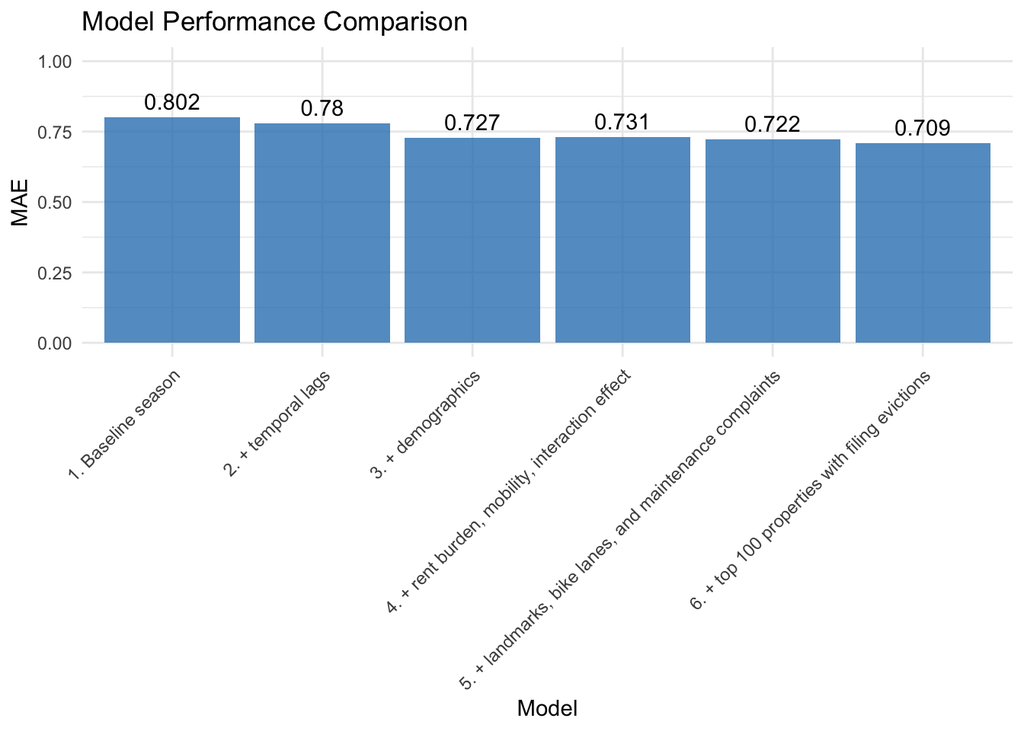

```r
model_comparison <- ggplot(mae_baseline, aes(x = Model, y = MAE)) +
  geom_col(fill = "#3182bd", alpha = .8) +
  geom_text(aes(label = round(MAE, 3)), vjust = -0.5) +
  labs(title = "Model Performance Comparison",
       x = "Model", y = "MAE") +
  theme_minimal() +
  theme(axis.text.x = element_text(angle = 45, hjust = 1)) +
  ylim(0, 1)


model_comparison
```

Performance improves as we add predictors, but most of the gain comes early. The baseline (Model 0), with only season and month, gives an MAE of 0.80 and an RMSE of 1.17. Adding the rolling four-week average and the 12-week lag in Model 1 drops MAE to 0.78 but pushes RMSE up to 1.62. The lags help on average but introduce a small number of large overpredictions in tracts where past activity does not predict forward cleanly. Model 2 adds tract-level demographics, which brings RMSE back down to 1.21 and MAE to 0.73. Models 3 and 4 add rent burden, mobility, the share-Black × rent-burdened interaction, landmarks, bike lanes, and 311 maintenance complaints, but the marginal gains are small. Our final specification, Model 5, adds the count of top-100 filer hotspots per tract and performs best overall, with an MAE of 0.71 and RMSE of 1.16.

# 8. Diagnostic and Error Analysis (Model 5)

## 8.1 Spatial Error Analysis

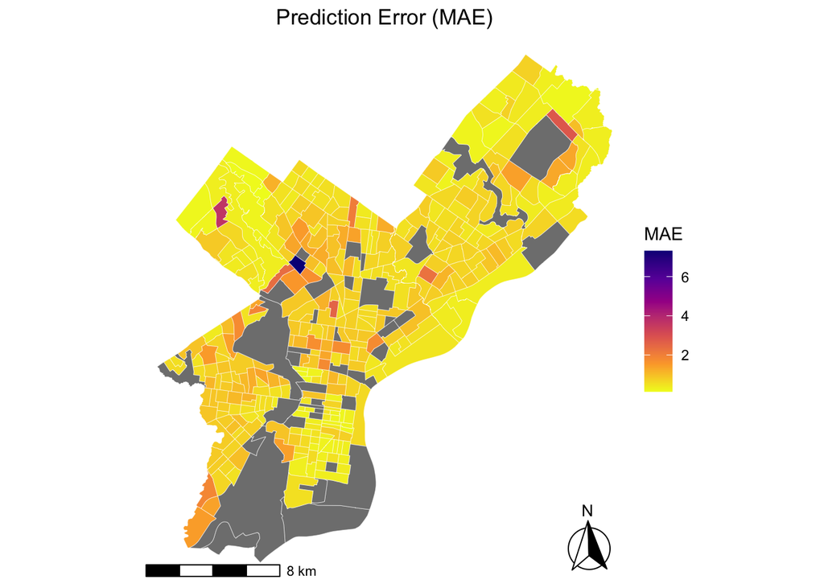

```r
# --- Create prediction error ---
test <- test %>%
  mutate(
    error = filings_2020 - pred5,
    abs_error = abs(error),
    pct_error = (pred5 - filings_2020) / (filings_2020 +1) * 100)

# --- Aggregate errors at tract level ---
tract_errors <- test %>%
  filter(!is.na(pred5)) %>%
  group_by(GEOID) %>%
  summarise(
    MAE = mean(abs_error, na.rm = TRUE),
    avg_eviction_filing = mean(filings_2020, na.rm = TRUE),
    prediction = mean(pred5, na.rm = TRUE),
    .groups = "drop"
  )

# --- Join to spatial geometry ---
tract_errors_sf <- census_tracts %>%
  left_join(tract_errors, by = "GEOID")

# --- Map 1: Prediction error ---
p1 <- ggplot() +
  geom_sf(
    data = tract_errors_sf,
    aes(fill = MAE),
    color = "white",
    linewidth = 0.1
  ) +
   # --- North arrow ---
  annotation_north_arrow(
    location = "br",   # top right
    which_north = "true",
    style = north_arrow_fancy_orienteering
  ) +

  # --- Scale bar ---
  annotation_scale(
    location = "bl",   # bottom left
    width_hint = 0.3
  ) +
    scale_fill_viridis_c(option = "plasma", direction = -1) +
  labs(title = "Prediction Error (MAE)") +
 theme_void() +
  theme(plot.title = element_text(hjust = 0.5))

# --- Map 2: Observed eviction rates ---
p2 <- ggplot() +
  geom_sf(
    data = tract_errors_sf,
    aes(fill = avg_eviction_filing),
    color = "white",
    linewidth = 0.1
  ) +
  scale_fill_viridis_c(option = "plasma", direction = -1) +
  labs(title = "Observed Eviction Filing") +
  theme_void() +
  theme(plot.title = element_text(hjust = 0.5))


p3 <- ggplot() +
  geom_sf(
    data = tract_errors_sf,
    aes(fill = prediction),
    color = "white",
    linewidth = 0.1
  ) +
  scale_fill_viridis_c(option = "plasma", direction = -1)+
  labs(title = "Predicted Eviction Filing") +
  theme_void() +
  theme(plot.title = element_text(hjust = 0.5))


(p1)
```

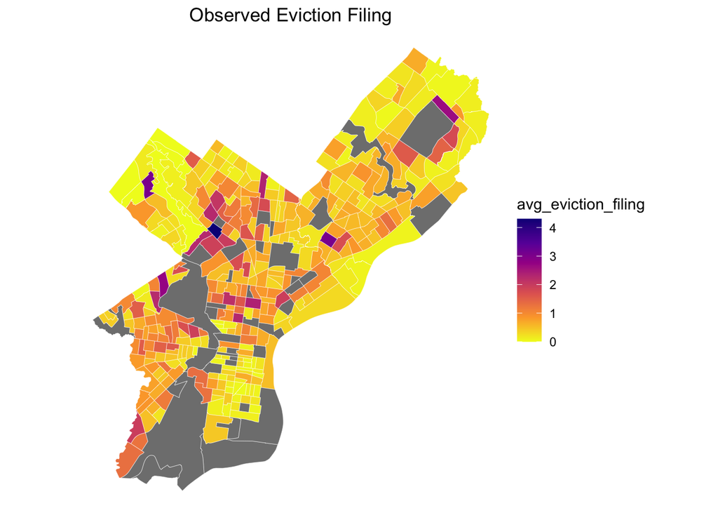

```r
(p2)
```

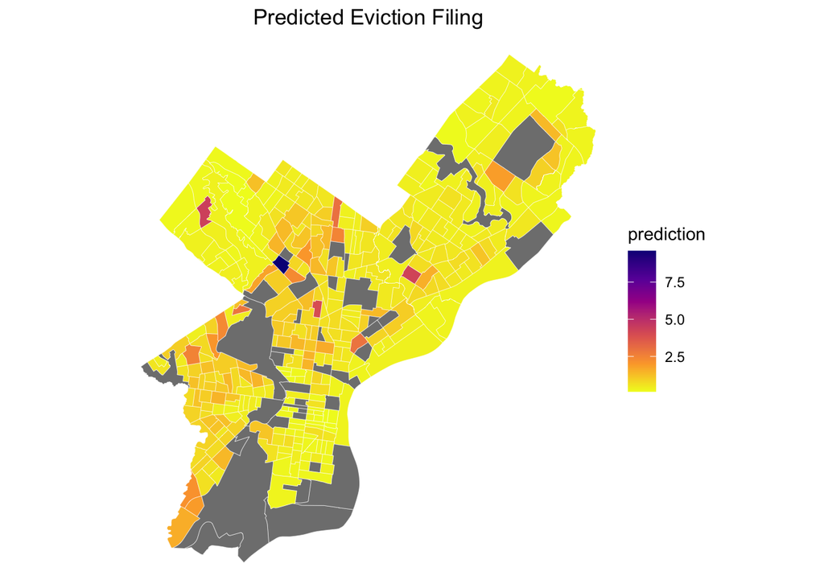

```r
(p3)
```

## 8.2 Temporal Error Analysis

The temporal error analysis evaluates the consistency of Model 5’s performance across times of the year by aggregating MAE by season. Eviction filings in Philadelphia often follow cyclical patterns, so it is important to ensure that the model does not lose predictive power during specific months. We calculate the average absolute distance between predicted and observed filings for winter, spring, summer, and fall.

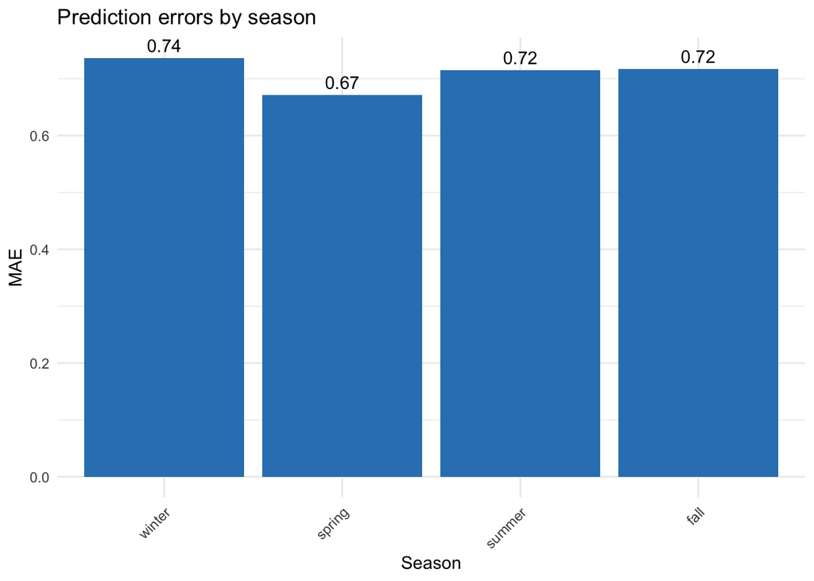

```r
# Aggregate Model 5 errors by season and pre/post-law period
temporal_errors <- test %>%
  filter(!is.na(pred5)) %>%
  mutate(
    season         = factor(season, levels = c("winter", "spring", "summer", "fall"))
  ) %>%
  group_by(season) %>%
  summarise(
    MAE = mean(abs_error, na.rm = TRUE),
    n   = n(),
    .groups = "drop"
  )

p9 <- ggplot(temporal_errors, aes(x = season, y = MAE,)) +
  geom_col(fill = "#3182bd", position = "dodge") +
  geom_text(aes(label = round(MAE, 2)), vjust = -.5) +
  labs(
    title = "Prediction errors by season",
    x     = "Season",
    y     = "MAE",
    fill  = "Policy period"
  ) +
  theme_minimal() +
  theme(axis.text.x = element_text(angle = 45, hjust = 1))

p9
```

The seasonal MAE plot shows that performance is broadly stable across the calendar year. Errors range from 0.67 in spring to 0.74 in winter. Spring is our best-performing season, winter is our worst, but the spread of 0.07 is small relative to the overall MAE of 0.71 and unlikely to reflect a meaningful seasonal weakness in the specification. Winter being slightly harder is consistent with our understanding of eviction filings in Philadelphia. Spring’s strong performance likely reflects that filings then most closely follow the rolling-average and 12-week lag patterns that drive the model.

We can conclude that the residual error is overwhelmingly cross-sectional rather than temporal. The models issues are in predicting tract-level intensity.

## 8.3 Demographic Error Analysis

To check whether prediction errors track structural neighbourhood characteristics, we plotted tract-level MAE against four demographic variables: median household income, share of rent-burdened households, share Black, and share Hispanic.

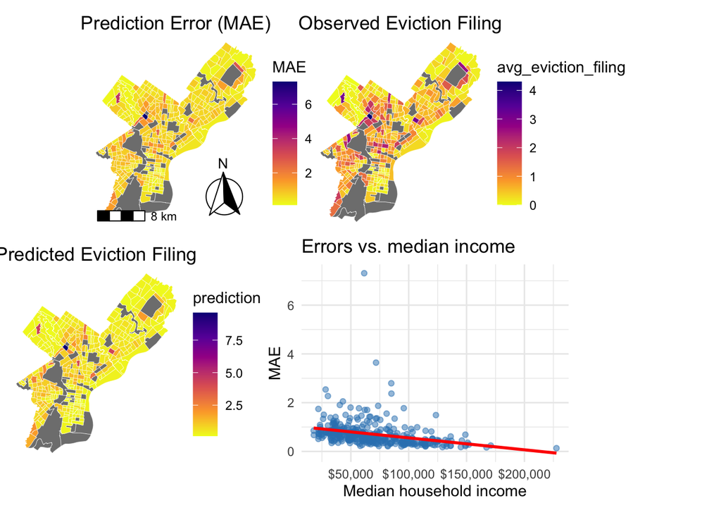

```r
# Aggregate Model 5 errors and demographics by tract
tract_errors_demo <- test %>%
  filter(!is.na(pred5)) %>%
  group_by(GEOID) %>%
  summarise(
    MAE                  = mean(abs_error, na.rm = TRUE),
    Med_Inc              = first(Med_Inc),
    share_rent_burdened  = first(share_rent_burdened),
    share_black          = first(share_black),
    share_hispanic       = first(share_hispanic),
    .groups              = "drop"
  ) %>%
  filter(!is.na(Med_Inc))

p4 <- ggplot(tract_errors_demo, aes(x = Med_Inc, y = MAE)) +
  geom_point(alpha = 0.5, color = "#3182bd") +
  geom_smooth(method = "lm", se = FALSE, color = "red") +
  scale_x_continuous(labels = scales::dollar) +
  labs(title = "Errors vs. median income",
       x = "Median household income", y = "MAE") +
  theme_minimal()

p5 <- ggplot(tract_errors_demo, aes(x = share_rent_burdened, y = MAE)) +
  geom_point(alpha = 0.5, color = "#3182bd") +
  geom_smooth(method = "lm", se = FALSE, color = "red") +
  labs(title = "Errors vs. rent burden",
       x = "% rent-burdened (30%+ of income on rent)", y = "MAE") +
  theme_minimal()

p6 <- ggplot(tract_errors_demo, aes(x = share_black, y = MAE)) +
  geom_point(alpha = 0.5, color = "#3182bd") +
  geom_smooth(method = "lm", se = FALSE, color = "red") +
  labs(title = "Errors vs. share Black",
       x = "% Black", y = "MAE") +
  theme_minimal()

p7 <- ggplot(tract_errors_demo, aes(x = share_hispanic, y = MAE)) +
  geom_point(alpha = 0.5, color = "#3182bd") +
  geom_smooth(method = "lm", se = FALSE, color = "red") +
  labs(title = "Errors vs. share Hispanic",
       x = "% Hispanic", y = "MAE") +
  theme_minimal()

(p1 | p2) / (p3 | p4)
```

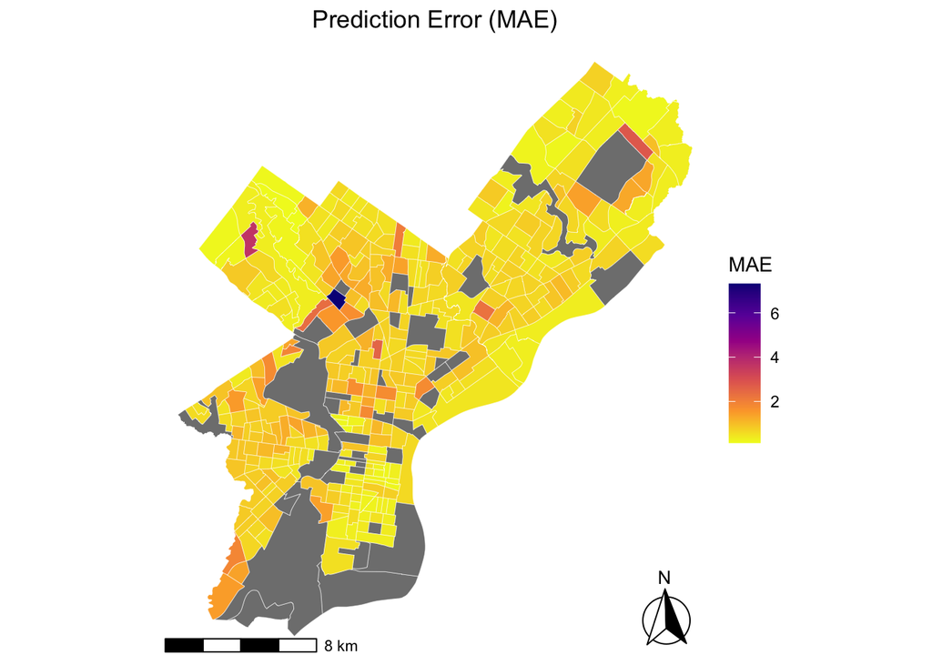

```r
p1
```

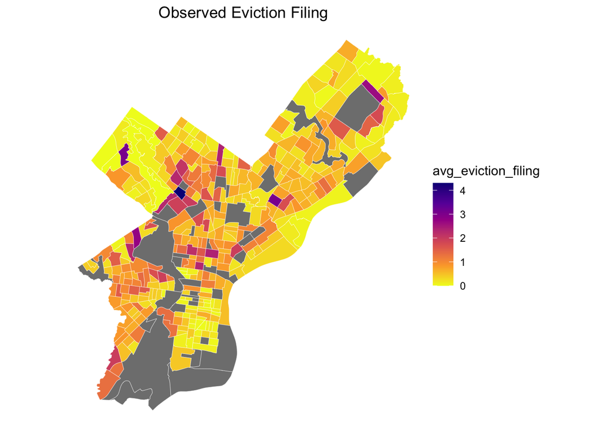

```r
p2
```

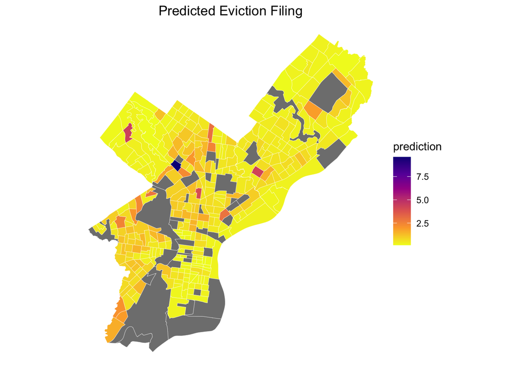

```r
p3
```

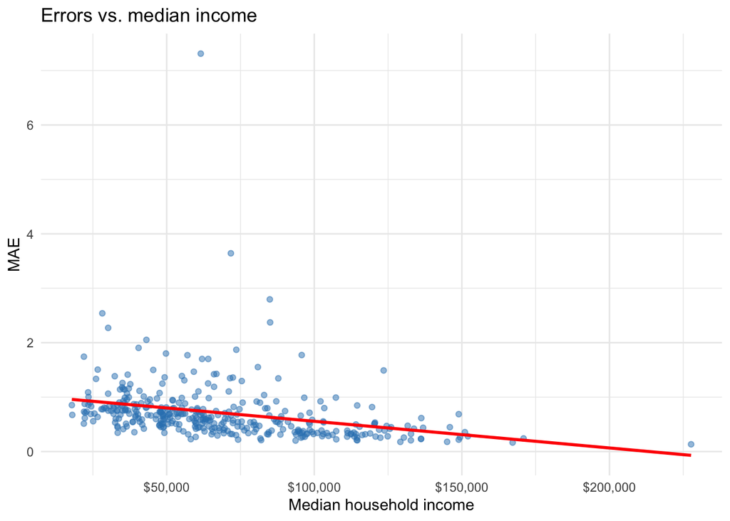

```r
p4
```

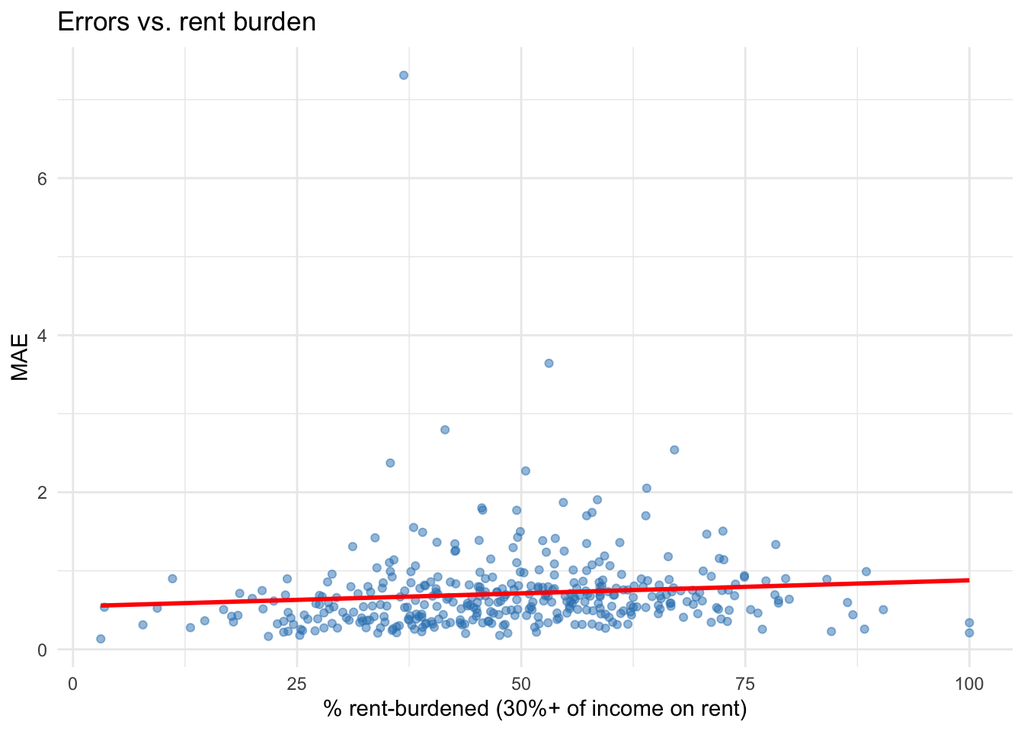

```r
p5
```

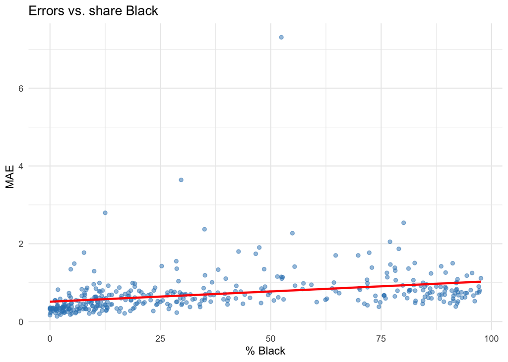

```r
p6
```

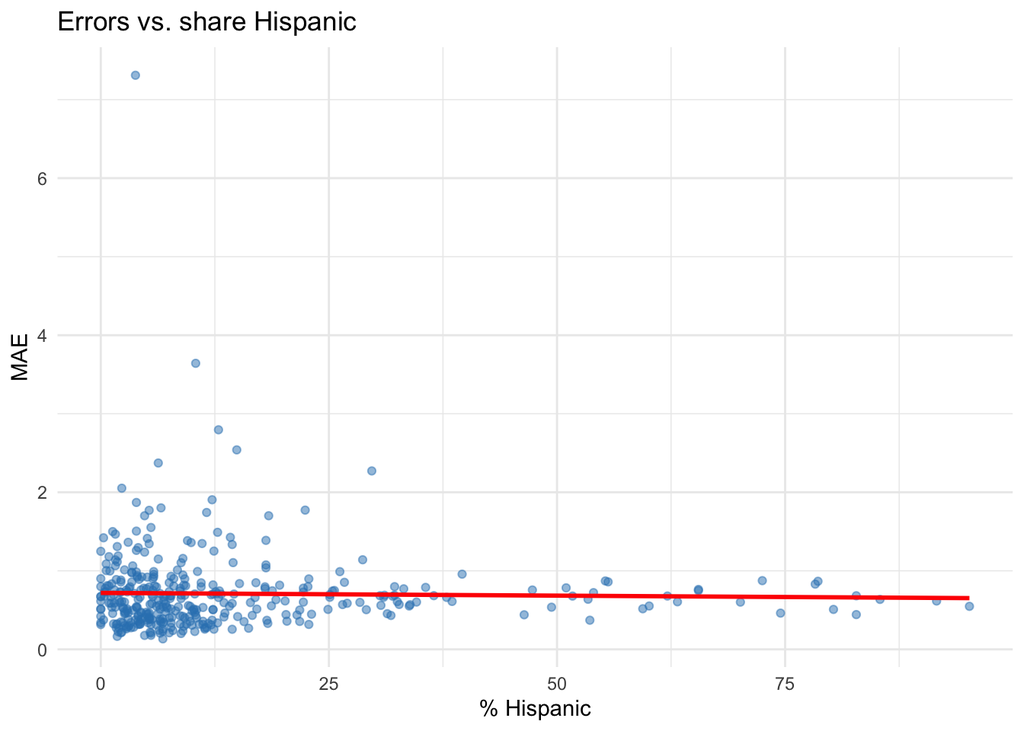

```r
p7
```

That being said, the negative relationship between median income provides further evidence that our model predicts better in tracts with fewer eviction filings (wealthy areas).